# Phyloseq demo

R Vannette

June 29, 2015

## Load packages and data

```r
#getwd()
#setwd() # change this to the location of your data


# load packages
#install.packages("phyloseq")
#install.packages("ape")
library(phyloseq)
library(ape)

# get files
# sample data
samp_dat <- read.csv("data/Centralia_Full_Map.txt",
                       sep = "\t", header = T )

rownames(samp_dat) <- samp_dat$X.SampleID #row names must match OTU table headers

SAMP <- sample_data(samp_dat)

# biom file
biom <- import_biom("data/otu_table_mc2_json.biom", header=T)
OTU <- otu_table(biom, taxa_are_rows = TRUE)
```

Note: the .biom table should be in json format. See http://biom-format.org/ for more details.

If you’re working with mothur output files, phyloseq has the `import_mothur` command that allows the user to import the shared/otu table, taxonomy, and phylogenetic tree files into phyloseq in one command.

```r
# taxonomy file
taxonomy<-read.table("data/rep_set_tax_assignments.txt", sep="\t", header=F)

###
#code to split up the taxonomy string #
##

tax<-as.character(taxonomy$V2)
head(tax)
```

```
## [1] "k__Bacteria; p__Proteobacteria; c__Betaproteobacteria; o__MND1; f__; g__; s__"
## [2] "k__Bacteria; p__Elusimicrobia; c__Elusimicrobia; o__Elusimicrobiales; f__; g__; s__"
## [3] "k__Bacteria; p__Proteobacteria; c__Deltaproteobacteria; o__Desulfuromonadales; f__Geobacteraceae; g__; s__"
## [4] "k__Bacteria; p__Acidobacteria; c__Solibacteres; o__Solibacterales; f__; g__; s__"
## [5] "k__Bacteria; p__Proteobacteria; c__Betaproteobacteria; o__SBla14; f__; g__; s__"
## [6] "k__Bacteria; p__Proteobacteria; c__Alphaproteobacteria; o__Rhodospirillales; f__Rhodospirillaceae; g__; s__"
```

```r
#root<-NA
Kingdom<-NA
Phylum<-NA
Class<-NA
Order<-NA
Family<-NA
Genus<-NA
Species<-NA

linaean<-data.frame(Kingdom,Phylum,Class,Order,Family,Genus,Species)

for (i in 1:dim(taxonomy)[1]) {

  split.tax<-strsplit(tax[i],split=c(";"))
  linaean[i,1]<-substr(split.tax[[1]][1], 4,30)
  linaean[i,2]<-substr(split.tax[[1]][2], 4,30)
  linaean[i,3]<-substr(split.tax[[1]][3], 4,30)
  linaean[i,4]<-substr(split.tax[[1]][4], 4,30)
  linaean[i,5]<-substr(split.tax[[1]][5], 4,30)
  linaean[i,6]<-substr(split.tax[[1]][6], 4,30)
  linaean[i,7]<-substr(split.tax[[1]][7], 4,30)
}
##

# remove underscore before taxon name
rownames(linaean) <- taxonomy$V1
for(i in 2:7){
linaean[,i] <- gsub("_","",linaean[,i])
}

TAX <- tax_table(as.matrix(linaean))



# tree file
tre<-read.tree("data/rep_set.tre")
# tree tip labels must match OTU names above.
```

## Combine the data into a phyloseq-class object

Note that phyloseq works with a **phyloseq-class object**, which is an object that has 4 types of data inside of it:  
1. OTU Table: Known as `otu_table()`  
2. Taxonomy File: Known as `tax_table()`  
3. Metadata File with sample information: Known as `sample_data()`  
4. Phylogenetic Tree File: Known as `phy_tree()`

```r
# Put the 4 data types together into a phyloseq-class object
myphy<- phyloseq(OTU, TAX, SAMP, tre)
```

## Data filtering and subsampling

Filter out OTUs that do not match Kingdom Bacteria

```r
dim(otu_table(myphy)) #check dimensions of the otu table
```

```
## [1] 25302    54
```

```r
myphy_f <- subset_taxa(myphy, Kingdom=="Bacteria") #include all OTUS identified as Bacteria
dim(otu_table(myphy_f)) #check how many were excluded
```

```
## [1] 22712    54
```

```r
myphy_f <- subset_taxa(myphy_f, Class!="Chloroplast") #exclude all OTUS identified as Chloroplast
dim(otu_table(myphy_f)) #check how many were excluded
```

```
## [1] 22557    54
```

Normalize/rarefy OTU table (once)

```r
myphy_f_rare <- rarefy_even_depth(myphy_f, rngseed=1) #record seed and # of OTUs removed
```

```
## `set.seed(1)` was used to initialize repeatable random subsampling.
## Please record this for your records so others can reproduce.
## Try `set.seed(1); .Random.seed` for the full vector
## ...
## 3413OTUs were removed because they are no longer
## present in any sample after random subsampling
##
## ...
```

## Estimate and plot within-sample diversity

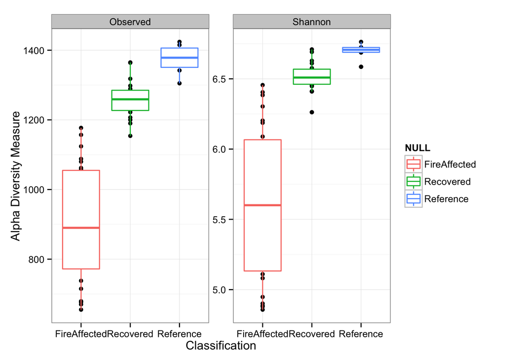

```r
library(ggplot2)

plot_richness(myphy_f_rare, x="Classification",
              measures=c("Observed", "Shannon"))+
  geom_boxplot(aes(color=Classification))+
  theme_bw()
```

## Comparative diversity and ordination

```r
library(vegan)
GPdist = phyloseq::distance(myphy_f_rare, "bray") # create bray-curtis distance matrix
GP.ord <- ordinate(myphy_f_rare, "NMDS", "bray") # NMDS ordination
```

```
## Square root transformation
## Wisconsin double standardization
## ... procrustes: rmse 0.0002228192  max resid 0.00121724
## *** Solution reached
```

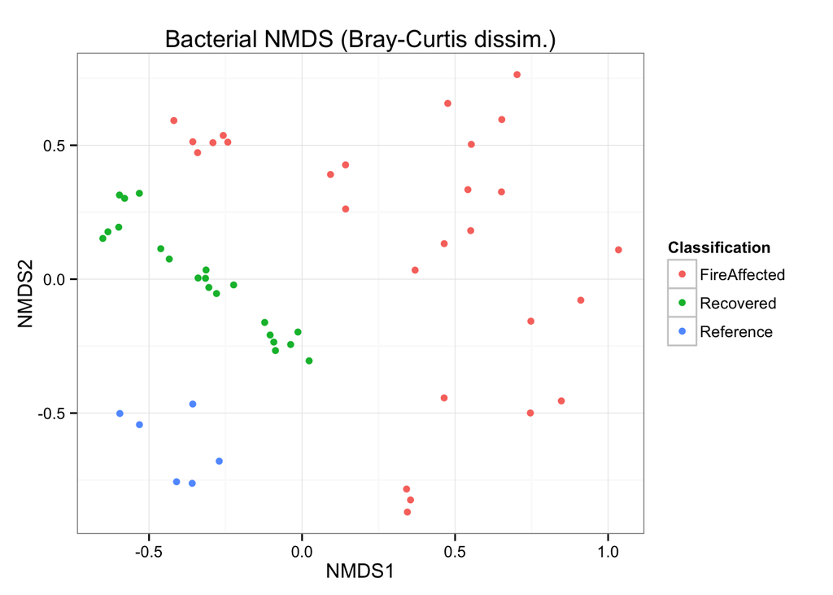

```r
plot_ordination(myphy_f_rare, ordination = GP.ord, type = "samples",
                color = "Classification",   title = "Bacterial NMDS (Bray-Curtis dissim.)")+theme_bw()
```

```r
adonis(GPdist~Classification,  as(sample_data(myphy_f_rare), "data.frame")) #Are there significant changes?
```

```
##
## Call:
## adonis(formula = GPdist ~ Classification, data = as(sample_data(myphy_f_rare),      "data.frame"))
##
## Permutation: free
## Number of permutations: 999
##
## Terms added sequentially (first to last)
##
##                Df SumsOfSqs MeanSqs F.Model      R2 Pr(>F)
## Classification  2    3.4991 1.74955  5.6588 0.18161  0.001 ***
## Residuals      51   15.7679 0.30917         0.81839
## Total          53   19.2670                 1.00000
## ---
## Signif. codes:  0 '***' 0.001 '**' 0.01 '*' 0.05 '.' 0.1 ' ' 1
```

*Combine all taxa assigned to the same Class for these analysis, otherwise plotting the tree and barplot can take a long time.*

Here, we combine all OTUs with the same taxonomic classification at the level of Class

```r
dim(otu_table(myphy_f_rare)) #check dimensions of the otu table
```

```
## [1] 19144    54
```

```r
myphy_Class <- tax_glom(myphy_f_rare, taxrank="Class") #agglomerate taxa based on class level

dim(otu_table(myphy_Class))
```

```
## [1] 113  54
```

## Composition barplots

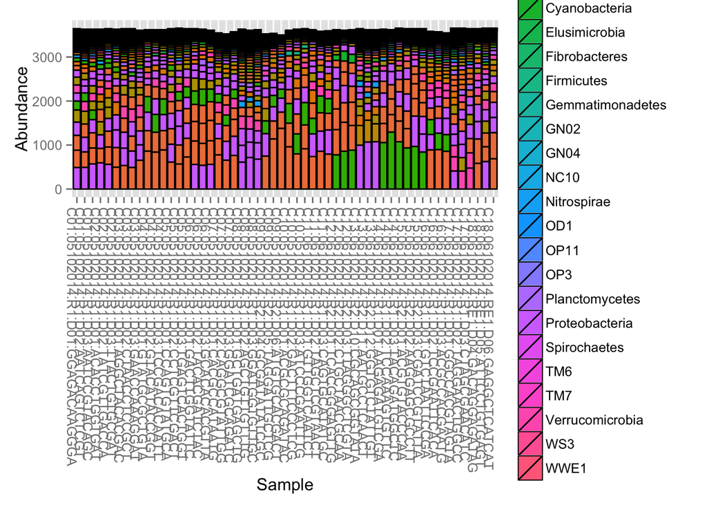

```r
plot_bar(myphy_Class, fill="Phylum")
```

Now merge replicates and re-make plots

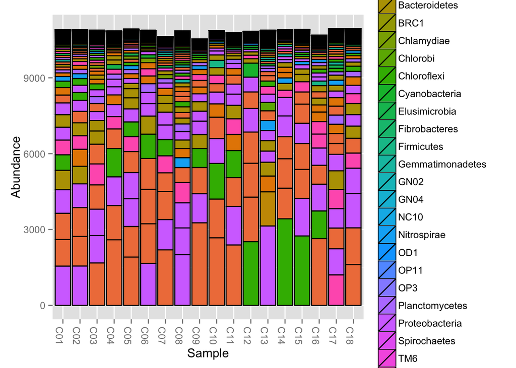

```r
myphy_Class_merged <- merge_samples(myphy_Class, "Sample")

plot_bar(myphy_Class_merged, fill = "Phylum")
```

## Phylogenetic tree

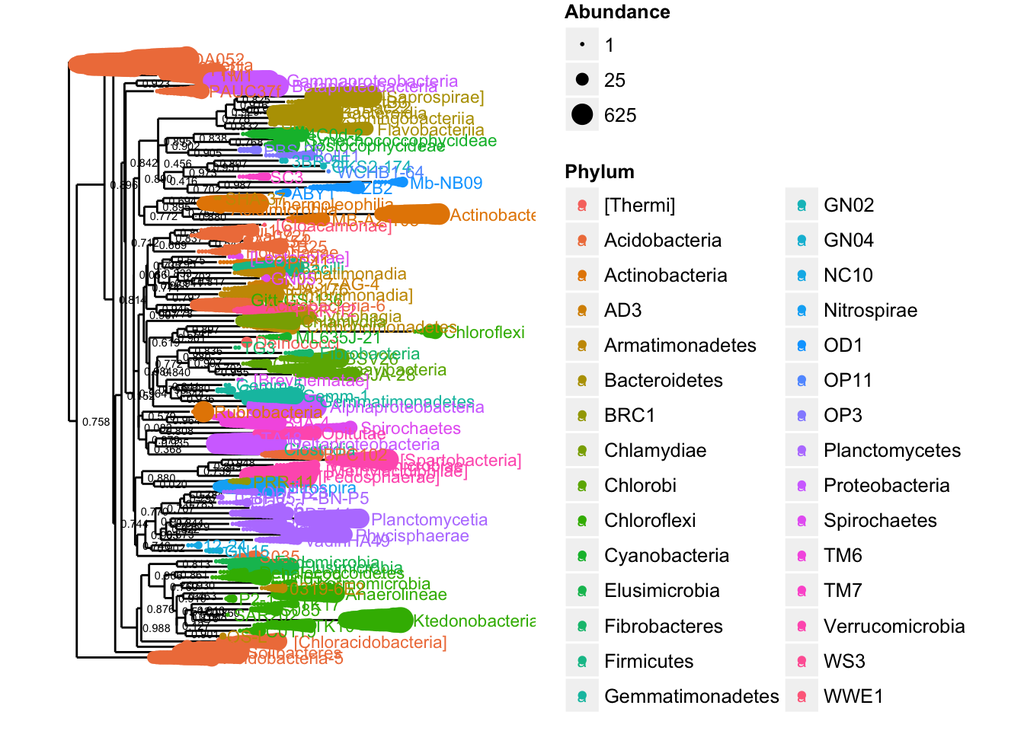

```r
quartz()
plot_tree(myphy_Class_merged,
          color = "Phylum",
          label.tips = "Class",
          base.spacing = 0.01,
          text.size = 3,
          size = "Abundance")+
  guides(color=guide_legend(ncol=2))
```

## Subsetting made easy

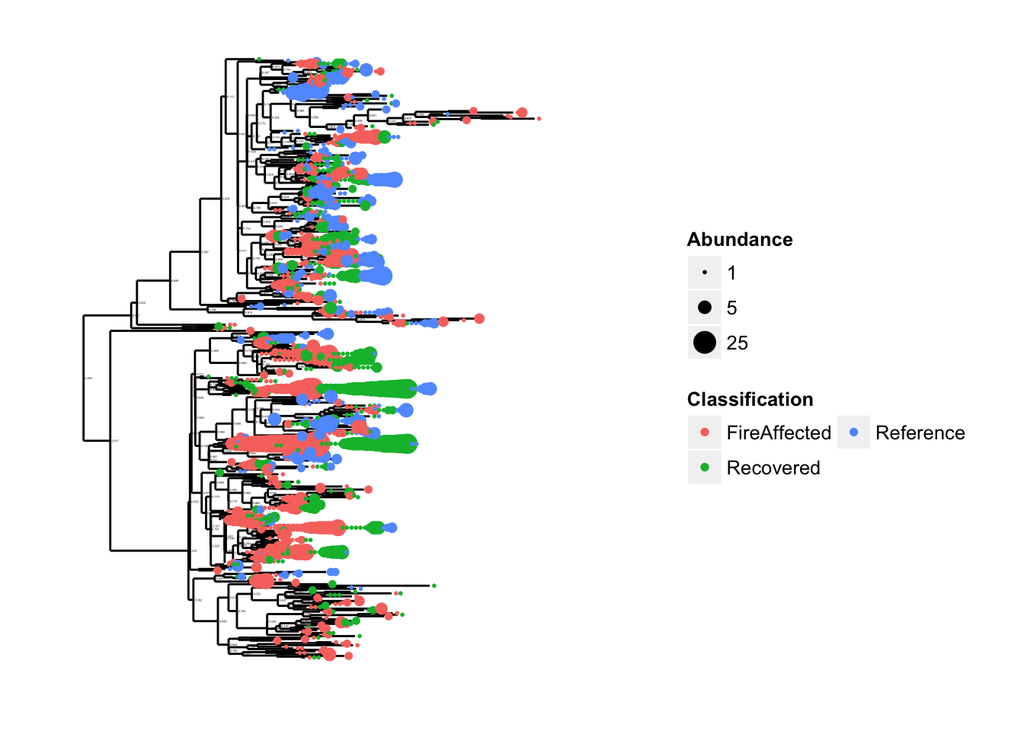

```r
myphy_thermo <- subset_taxa(myphy_f_rare, Class=="Thermoleophilia")
quartz()
plot_tree(myphy_thermo,
          color = "Classification",
          #label.tips = "Family",
          base.spacing = 0.01,
          text.size = 2,
          size = "Abundance")+
  guides(color=guide_legend(ncol=2))
```

## Other resources

Phyloseq main page with links to tutorials: https://joey711.github.io/phyloseq/

RDP tutorials with phyloseq: https://rdp.cme.msu.edu/tutorials/stats/using_rdp_output_with_phyloseq.html